# Leiden clustering and autocorrelation: worked examples

Crystal Shan

## Overview

This tutorial accompanies `selectFiberseqLociWorkflow` 0.99.1 or later and follows the [function-reference tutorial](https://crystalshann.github.io/plot_selected_Fiber-seq_loci/function-reference.html) format: function tables, executable examples, plots, and result exports.

**Leiden clustering** and **autocorrelation** have separate sections below. Leiden groups reads by their m6A patterns. Autocorrelation describes repeating patterns within each read as a function of distance in base pairs. ACF profiles can also be clustered with their own independent Leiden analysis.

| Analysis | Input features | Controls | Result location |
| --- | --- | --- | --- |
| Manhattan-distance Leiden | Observed m6A sites or bins | `clustering`, `window_size`, `k_neighbors`, `resolution`, `seed` | Locus `colData$cluster` and `metadata$clustering` |
| Autocorrelation | All consecutive bases in the locus | `autocorrelation`, `max_lag` | Separate ACF experiment with lags in rows |
| Optional ACF clustering | PCA of the ACF profiles | ACF `clustering`, `n_pcs`, `n_neighbors`, `resolution`, `seed` | ACF `colData$acf_cluster` and ACF metadata |

The two top-level switches are independent. They use the **same sample sheet**. ACF settings do not change the m6A assay, read order or Manhattan cluster labels.

### Functions used

| Function | What it does |
| --- | --- |
| `make_sample_sheet()` / `prepare_regions()` | Define the shared inputs. |
| `analyze_loci()` | Extract full-span reads; optionally run either analysis. |
| `locus_autocorrelation()` | Compute ACF on an existing locus without rereading tracks. |
| `autocorrelation_profile()` | Report means, SD, SEM and valid/invalid read counts. |
| `plot_autocorrelation()` | Draw mean curves or a per-read heatmap. |
| `write_autocorrelation_results()` | Export the ACF experiment, tables and PDFs. |
| `write_locus_results()` | Export locus results and any attached ACF results. |

## Before you start

Install version 0.99.1 or later of the package following its README. The extra R packages `uwot` and `irlba` are needed only for ACF clustering. This tutorial uses them in the worked clustering examples. Python is not required.

```r
install.packages(c("uwot", "irlba"))
```

```r
library(selectFiberseqLociWorkflow)
library(SummarizedExperiment)
library(GenomicRanges)
stopifnot(packageVersion("selectFiberseqLociWorkflow") >= "0.99.1")
stopifnot(requireNamespace("uwot", quietly = TRUE),
          requireNamespace("irlba", quietly = TRUE))
```

### Download the LCL subset and VCFs

Download these two files into the same directory:

- R Markdown tutorial
- Actual LCL example data, including VCFs (ZIP)

The example contains **33 actual reads** from two libraries at rs12470189: **AL16 / NA18508 (15 reads)** and **AL30 / NA18510 (18 reads)**. It includes all reads retained for these libraries in the saved native R ACF input, with no selection by peak strength, allele, ACF profile, or clustering result. The analysis interval is **chr2:119290056–119292055** (one-based inclusive). The variants and m6A calls are extracted from your existing processed files.

| Included file | Purpose |
| --- | --- |
| Two `*.m6a.bed.gz` files and `.tbi` indexes | Original full-span BED12 alignment records, copied without changing calls or coordinates. |
| Two `*.region.vcf.gz` files and `.tbi` indexes | Variants within the analysis window, retaining only the matching cell-line genotype column in each VCF. |
| `samples.tsv`, `regions.tsv` | Portable sample sheet and locus coordinates. |
| `read_phasing.tsv` | Existing per-molecule HP, phase set, focal genotype and allele label. |
| `reference.rds` | Corresponding saved binary inputs and native R per-read ACFs for verification. |
| `provenance.tsv`, `source_checksums.tsv`, `checksums.tsv` | Source files, subset details, and checksum records. |
| `prepare-lcl-subset.R` | R extraction script for rebuilding the download from the original project. |

The VCF’s fixed fields, FORMAT and selected GT/PS values are preserved. Its INFO annotations, including allele frequency, describe the original source cohort and are not recomputed for this subset. Full BED alignment boundaries are retained; only calls within the selected 2,000-bp locus enter the analysis.

The default tutorial runs entirely from the ZIP and installed R packages; it does not require access to the original project directories. A later optional section repeats the analysis using the full 255-read saved LCL input.

```r
# Downloadable LCL subset, including regional VCFs.
rmarkdown::render("autocorrelation-tutorial.Rmd")

# Also include the full saved LCL cohort on the project filesystem.
rmarkdown::render("autocorrelation-tutorial.Rmd",
    params = list(run_lcl = TRUE, project = "/project/spott/cshan/fiber-seq"))
```

`example_zip` can point to the ZIP elsewhere. Set `output_dir` to a new or empty folder to retain exports; the default uses a temporary directory. `run_lcl` controls only the optional full-cohort section. The default downloadable example always uses actual LCL data. The values used for this render are:

```r
knitr::kable(data.frame(setting = c("package_version", "run_full_lcl", "lcl_region"),
    value = c(as.character(packageVersion("selectFiberseqLociWorkflow")),
              params$run_lcl, params$lcl_region)))
```

| setting | value |
| --- | --- |
| package_version | 0.99.1 |
| run_full_lcl | TRUE |
| lcl_region | rank01_rs12470189_chr2_119290945_119291178 |

```r
run_dir <- if (is.null(params$output_dir)) tempfile("acf-tutorial-results-") else
    path.expand(params$output_dir)
if (file.exists(run_dir) && (!dir.exists(run_dir) ||
    length(list.files(run_dir, all.files = TRUE, no.. = TRUE))))
    stop("Choose a new or empty output_dir")
dir.create(run_dir, recursive = TRUE, showWarnings = FALSE)
```

## Prepare the shared LCL example inputs

### Unzip and verify the files

Paths are relative to `samples.tsv`, so the download is portable. The code extracts into a new temporary directory on each run. The `vcf` and `vcf_sample` columns are additional metadata used explicitly below; the package’s core m6A clustering and ACF methods do not require VCF input.

```r
stopifnot(file.exists(params$example_zip))
data_dir <- tempfile("acf-lcl-input-")
dir.create(data_dir)
unzip(params$example_zip, exdir = data_dir)
data_dir <- file.path(data_dir, "lcl-autocorrelation-example")
checksums <- read.delim(file.path(data_dir, "checksums.tsv"))
stopifnot(identical(unname(tools::md5sum(file.path(data_dir, checksums$file))),
                    checksums$md5))
samples <- make_sample_sheet(file.path(data_dir, "samples.tsv"))
region_table <- read.delim(file.path(data_dir, "regions.tsv"))
regions <- prepare_regions(region_table, coordinate_system = "bed")
validate_inputs(samples, regions)
phasing <- read.delim(file.path(data_dir, "read_phasing.tsv"), colClasses = "character")
reference <- readRDS(file.path(data_dir, "reference.rds"))
knitr::kable(as.data.frame(samples)[, c("sample_name", "sample_label", "vcf_sample", "m6a_format")])
```

| sample_name | sample_label | vcf_sample | m6a_format |
| --- | --- | --- | --- |
| AL16_bc2114_18508 | AL16 | NA18508 | bed12_fibertools |
| AL30_bc2179_18510 | AL30 | NA18510 | bed12_fibertools |

```r
regions
```

```
#> GRanges object with 1 range and 6 metadata columns:
#>                                              seqnames              ranges
#>                                                 <Rle>           <IRanges>
#>   rank01_rs12470189_chr2_119290945_119291178     chr2 119290056-119292055
#>                                              strand |              region_id
#>                                               <Rle> |            <character>
#>   rank01_rs12470189_chr2_119290945_119291178      * | rank01_rs12470189_ch..
#>                                                focal_snp focal_pos         ref
#>                                              <character> <integer> <character>
#>   rank01_rs12470189_chr2_119290945_119291178  rs12470189 119291056           G
#>                                                      alt       tss
#>                                              <character> <numeric>
#>   rank01_rs12470189_chr2_119290945_119291178           A        NA
#>   -------
#>   seqinfo: 1 sequence from an unspecified genome; no seqlengths
```

BED coordinates `[119290055, 119292055)` correspond to the one-based interval above. The original LCL pipeline retained full-span reads with at least one m6A call and a phased focal heterozygous genotype (HP1/HP2, `0|1` or `1|0`). That selection has already been applied to the downloadable BED files. This subset is a worked example, not an unfiltered estimate of population coverage.

### Inspect the included VCF and verify read phasing

A VCF describes variant genotypes, not molecule-to-haplotype assignments. We therefore include the existing read-level phasing table as well. This code reads the focal SNP from each VCF, checks its cell-line column and phase set, and verifies the saved allele labels. It does not infer new read phasing.

```r
read_focal_variant <- function(i) {
    path <- file.path(data_dir, samples$vcf[i])
    stopifnot(file.exists(path), file.exists(paste0(path, ".tbi")))
    header <- Rsamtools::headerTabix(path)$header
    columns <- strsplit(header[startsWith(header, "#CHROM\t")], "\t", fixed = TRUE)[[1]]
    sample_column <- match(samples$vcf_sample[i], columns)
    stopifnot(length(columns) == 10L, identical(sample_column, 10L))
    query <- GRanges(region_table$chr,
        IRanges::IRanges(region_table$focal_pos, width = 1L))
    lines <- Rsamtools::scanTabix(path, param = query)[[1]]
    fields <- strsplit(lines, "\t", fixed = TRUE)
    hit <- fields[vapply(fields, function(f)
        as.integer(f[2]) == region_table$focal_pos &&
        f[4] == region_table$ref && f[5] == region_table$alt, logical(1))]
    stopifnot(length(hit) == 1L)
    f <- hit[[1]]
    values <- setNames(strsplit(f[sample_column], ":", fixed = TRUE)[[1]],
        strsplit(f[9], ":", fixed = TRUE)[[1]])
    stopifnot(all(c("GT", "PS") %in% names(values)))
    data.frame(sample_name = samples$sample_name[i], vcf_sample = samples$vcf_sample[i],
        variant = f[3], ref = f[4], alt = f[5],
        genotype = unname(values["GT"]), phase_set = unname(values["PS"]))
}
focal_variants <- do.call(rbind, lapply(seq_len(nrow(samples)), read_focal_variant))
ix <- match(phasing$sample_name, focal_variants$sample_name)
stopifnot(!anyNA(ix), all(phasing$focal_genotype == focal_variants$genotype[ix]),
    all(phasing$phase_set == focal_variants$phase_set[ix]),
    all(phasing$haplotype %in% c("HP1", "HP2")),
    all(phasing$focal_genotype %in% c("0|1", "1|0")))
is_alt <- (phasing$haplotype == "HP2" & phasing$focal_genotype == "0|1") |
    (phasing$haplotype == "HP1" & phasing$focal_genotype == "1|0")
allele <- ifelse(is_alt, focal_variants$alt[ix], focal_variants$ref[ix])
stopifnot(all(phasing$allele_label == paste0(region_table$focal_snp, ": ", allele)))
knitr::kable(focal_variants)
```

| sample_name | vcf_sample | variant | ref | alt | genotype | phase_set |
| --- | --- | --- | --- | --- | --- | --- |
| AL16_bc2114_18508 | NA18508 | rs12470189 | G | A | 0\|1 | 119099734 |
| AL30_bc2179_18510 | NA18510 | rs12470189 | G | A | 0\|1 | 117867471 |

```r
knitr::kable(as.data.frame(table(sample = phasing$sample_name, haplotype = phasing$haplotype)))
```

| sample | haplotype | Freq |
| --- | --- | --- |
| AL16_bc2114_18508 | HP1 | 9 |
| AL30_bc2179_18510 | HP1 | 11 |
| AL16_bc2114_18508 | HP2 | 6 |
| AL30_bc2179_18510 | HP2 | 7 |

## Leiden clustering

### Fit Manhattan-distance Leiden on the downloaded LCL reads

This section uses only the existing m6A clustering path. The settings here are separate from the ACF settings in the next section.

```r
leiden_results <- analyze_loci(samples, regions,
    clustering = TRUE, autocorrelation = FALSE,
    window_size = 0, k_neighbors = 10, resolution = 1, seed = 1)
x_leiden <- leiden_results[[1]]
# Carry the saved phasing annotations onto these exact molecules.
read_keys <- paste(colData(x_leiden)$sample_name, colData(x_leiden)$original_RID, sep = "__")
phasing_index <- match(read_keys, phasing$row_id)
stopifnot(!anyNA(phasing_index), setequal(read_keys, phasing$row_id))
for (field in c("haplotype", "phase_set", "focal_genotype", "allele_label", "allele_status"))
    colData(x_leiden)[[field]] <- phasing[[field]][phasing_index]
leiden_results[[1]] <- x_leiden
metadata(x_leiden)$clustering_status
```

```
#> [1] "complete"
```

```r
knitr::kable(as.data.frame(table(sample = colData(x_leiden)$sample_label,
    cluster = colData(x_leiden)$cluster)))
```

| sample | cluster | Freq |
| --- | --- | --- |
| AL16 | cluster1 | 8 |
| AL30 | cluster1 | 10 |
| AL16 | cluster2 | 7 |
| AL30 | cluster2 | 8 |

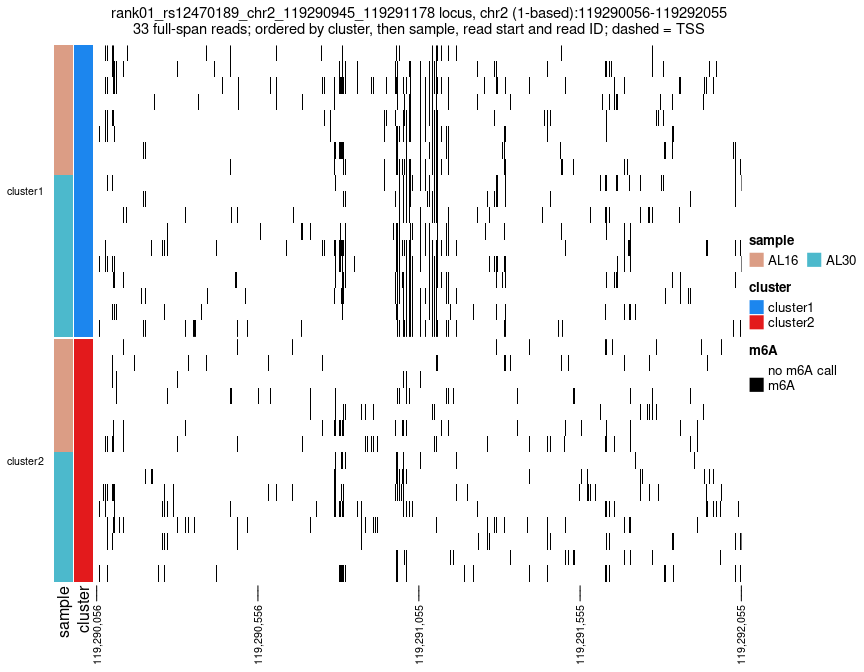

```r
ComplexHeatmap::draw(plot_locus(x_leiden, "heatmap", clustered = TRUE))
```

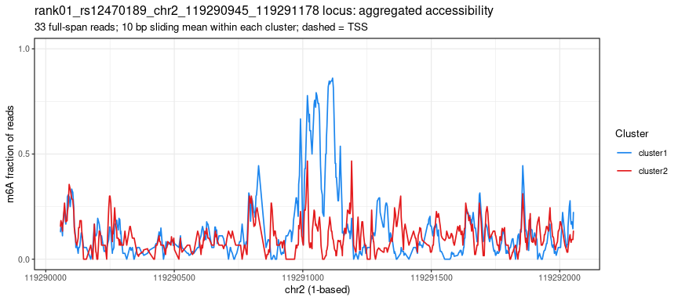

```r
plot_locus(x_leiden, "profile", clustered = TRUE)
```

Manhattan clustering compares calls at corresponding genomic positions. These labels describe the 33-read subset and need not reproduce the clusters from the full cohort. Neither VCF genotypes nor saved haplotype labels enter the Manhattan distance calculation.

## Autocorrelation

### `locus_autocorrelation()` — compute per-read ACFs

Compute ACF on the exact locus already used above. No input files are reread. `max_lag = 500` returns 501 features: lag zero through lag 500. Lag zero is one for a nonconstant read. Curves omit lag zero by default so other lags are easier to see. Constant reads have undefined (`NA`) ACF values.

```r
a <- locus_autocorrelation(x_leiden, max_lag = 500)
stopifnot(identical(colnames(a), colnames(x_leiden)),
          identical(colData(a)$cluster, colData(x_leiden)$cluster))
knitr::kable(as.data.frame(table(status = colData(a)$acf_status)))
```

| status | Freq |
| --- | --- |
| valid | 33 |

```r
head(rowData(a))
```

```
#> DataFrame with 6 rows and 1 column
#>         lag_bp
#>      <integer>
#> lag0         0
#> lag1         1
#> lag2         2
#> lag3         3
#> lag4         4
#> lag5         5
```

For a mean-centered binary read, ACF at lag *k* is the sum of products between bases *k* apart, divided by the fixed lag-zero sum of squares. The package uses `stats::acf()` with no smoothing and no lag-dependent overlap correction. All consecutive bases enter the calculation, including positions without calls.

### `autocorrelation_profile()` — summarize valid reads

```r
profile <- autocorrelation_profile(a, group_by = "sample")
knitr::kable(as.data.frame(profile[profile$lag_bp %in% c(0, 180, 220), ]), digits = 4)
```

| lag_bp | group | mean_acf | sd_acf | sem_acf | n_reads | n_valid | n_invalid |
| --- | --- | --- | --- | --- | --- | --- | --- |
| 0 | AL16_bc2114_18508 | 1.0000 | 0.0000 | 0.0000 | 15 | 15 | 0 |
| 180 | AL16_bc2114_18508 | 0.0087 | 0.0182 | 0.0047 | 15 | 15 | 0 |
| 220 | AL16_bc2114_18508 | -0.0064 | 0.0227 | 0.0059 | 15 | 15 | 0 |
| 0 | AL30_bc2179_18510 | 1.0000 | 0.0000 | 0.0000 | 18 | 18 | 0 |
| 180 | AL30_bc2179_18510 | 0.0246 | 0.0289 | 0.0068 | 18 | 18 | 0 |
| 220 | AL30_bc2179_18510 | 0.0050 | 0.0252 | 0.0059 | 18 | 18 | 0 |

```r
stopifnot(ncol(a) == nrow(phasing), all(colData(a)$acf_valid))
```

Means exclude constant reads; `n_reads`, `n_valid` and `n_invalid` make that exclusion visible. SD and SEM are `NA` with fewer than two valid reads. The included reads all have nonconstant m6A profiles. Real samples need not have similar ACF curves or a peak in the 140–250-bp band.

### `plot_autocorrelation()` — curves and heatmap

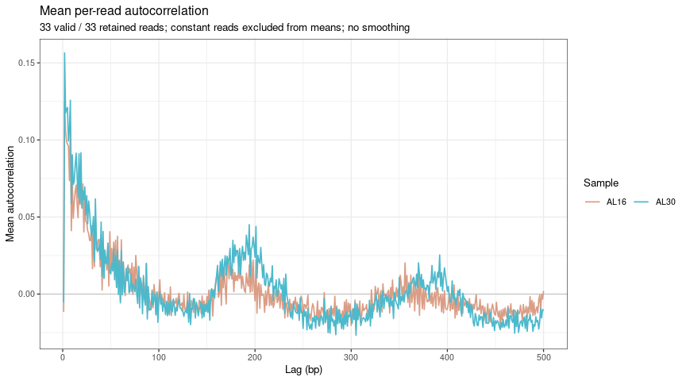

```r
plot_autocorrelation(a, group_by = "sample", lag_range = c(1, 500))
```

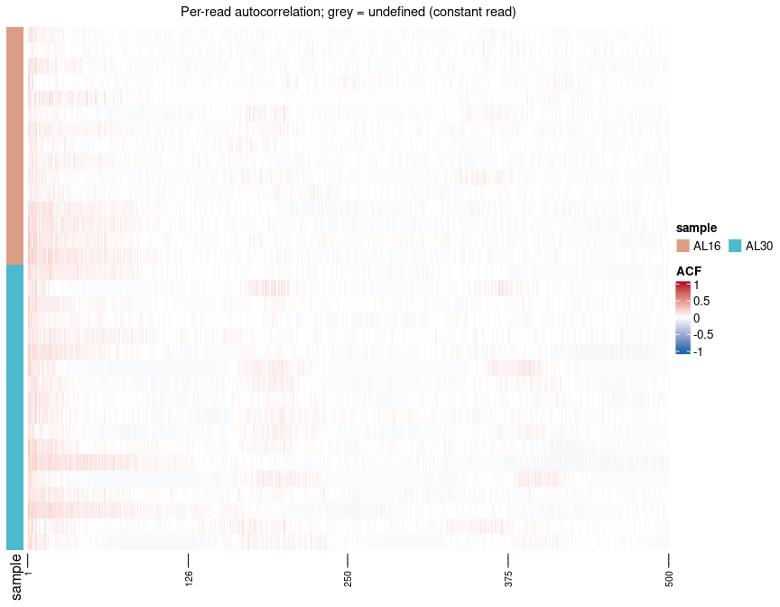

```r
ComplexHeatmap::draw(plot_autocorrelation(a, "heatmap", group_by = "sample"))
```

Use `group_by = "cluster"` to summarize by the original Manhattan clusters; this reads existing labels without fitting another clustering model.

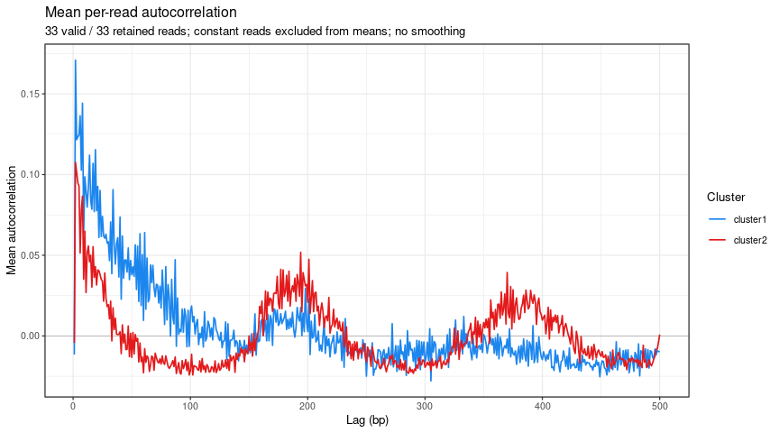

```r
plot_autocorrelation(a, group_by = "cluster")
```

### Optional clustering of ACF profiles

The ACF method uses centered, unscaled PCA; correlation-distance neighbors; a `uwot` fuzzy graph; and igraph Leiden clustering. UMAP coordinates are for display. The independent ACF labels are zero-based and stored in `acf_cluster`. The original `cluster` column retains the Manhattan labels.

```r
set.seed(123)
rng_before <- .Random.seed
acf_clustered <- locus_autocorrelation(x_leiden, max_lag = 500,
    clustering = TRUE, n_pcs = 50, n_neighbors = 10, resolution = 0.4, seed = 0)
stopifnot(identical(rng_before, .Random.seed),
    identical(colData(acf_clustered)$cluster, colData(x_leiden)$cluster))
knitr::kable(as.data.frame(table(status = colData(acf_clustered)$acf_cluster_status)))
```

| status | Freq |
| --- | --- |
| clustered | 33 |

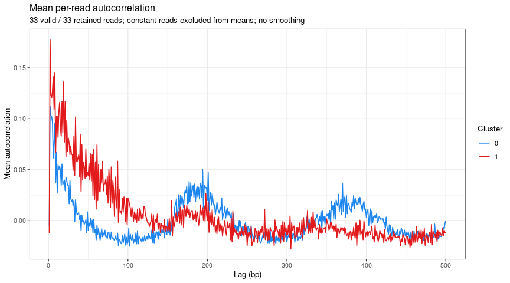

```r
plot_autocorrelation(acf_clustered, group_by = "acf_cluster")
```

Reads with constant ACFs or insufficient usable information keep explicit statuses. Unassigned reads are excluded from `acf_cluster` views but remain in all/sample summaries and exports. Fewer than four valid reads cannot form an ACF clustering fit.

### Verify the extracted calls and ACFs against the original run

The archive includes the corresponding rows of the original binary input and saved native R ACFs. These are used only after extraction and analysis, to check that the original calls, read identities and numerical normalization agree. The package uses `sample::read` IDs while the saved pipeline uses `sample__read`; matching uses the original sample and read fields explicitly.

```r
reference_index <- match(read_keys, reference$row_ids)
stopifnot(!anyNA(reference_index), length(read_keys) == length(reference$row_ids),
    identical(unname(t(as.matrix(assay(x_leiden, "m6a")))),
        unname(reference$binary[reference_index, , drop = FALSE])))
expected_acf <- reference$acf[reference_index, seq_len(nrow(a)), drop = FALSE]
observed_acf <- t(assay(a, "acf"))
stopifnot(identical(unname(is.na(observed_acf)), unname(is.na(expected_acf))))
max_difference_subset <- max(abs(observed_acf - expected_acf), na.rm = TRUE)
stopifnot(max_difference_subset < 1e-12)
knitr::kable(data.frame(check = c("Extracted reads", "Maximum absolute ACF difference"),
    value = c(length(read_keys), max_difference_subset)))
```

| check | value |
| --- | --- |
| Extracted reads | 33 |
| Maximum absolute ACF difference | 0 |

```r
peak_data <- as.data.frame(colData(acf_clustered))
knitr::kable(peak_data[, c("sample_name", "haplotype", "acf_cluster",
    "positive_local_peak_140_250_bp", "peak_acf")], digits = 4)
```

|  | sample_name | haplotype | acf_cluster | positive_local_peak_140_250_bp | peak_acf |
| --- | --- | --- | --- | --- | --- |
| AL16_bc2114_18508::m84241_250907_054529_s2/145887843/ccs | AL16_bc2114_18508 | HP1 | 0 | 172 | 0.0501 |
| AL16_bc2114_18508::m84241_250515_002859_s3/31394281/ccs | AL16_bc2114_18508 | HP2 | 0 | 223 | 0.0720 |
| AL16_bc2114_18508::m84241_250515_002859_s3/266864964/ccs | AL16_bc2114_18508 | HP1 | 0 | 186 | 0.0517 |
| AL16_bc2114_18508::m84241_250515_002859_s3/157422976/ccs | AL16_bc2114_18508 | HP2 | 0 | 204 | 0.0815 |
| AL16_bc2114_18508::m84241_250908_180102_s3/160175746/ccs | AL16_bc2114_18508 | HP1 | 1 | 175 | 0.0282 |
| AL16_bc2114_18508::m84241_250515_002859_s3/124587432/ccs | AL16_bc2114_18508 | HP2 | 0 | 174 | 0.1497 |
| AL16_bc2114_18508::m84241_250911_005634_s4/164301440/ccs | AL16_bc2114_18508 | HP1 | 1 | 198 | 0.1057 |
| AL16_bc2114_18508::m84241_250515_002859_s3/244388341/ccs | AL16_bc2114_18508 | HP2 | 0 | 164 | 0.1156 |
| AL16_bc2114_18508::m84241_250911_005634_s4/138151084/ccs | AL16_bc2114_18508 | HP1 | 1 | 172 | 0.0584 |
| AL16_bc2114_18508::m84241_250910_225330_s3/61605728/ccs | AL16_bc2114_18508 | HP2 | 0 | 183 | 0.0849 |
| AL16_bc2114_18508::m84241_250908_180102_s3/240125680/ccs | AL16_bc2114_18508 | HP2 | 0 | 224 | 0.1136 |
| AL16_bc2114_18508::m84241_250515_002859_s3/58261848/ccs | AL16_bc2114_18508 | HP1 | 1 | 158 | 0.0321 |
| AL16_bc2114_18508::m84241_250911_005634_s4/256644496/ccs | AL16_bc2114_18508 | HP1 | 1 | 214 | 0.0430 |
| AL16_bc2114_18508::m84241_250515_002859_s3/257888737/ccs | AL16_bc2114_18508 | HP1 | 1 | 175 | 0.0665 |
| AL16_bc2114_18508::m84241_250908_180102_s3/258540726/ccs | AL16_bc2114_18508 | HP1 | 1 | 196 | 0.0865 |
| AL30_bc2179_18510::m84241_250327_025853_s1/130552023/ccs | AL30_bc2179_18510 | HP1 | 1 | 226 | 0.0464 |
| AL30_bc2179_18510::m84241_250327_025853_s1/227938674/ccs | AL30_bc2179_18510 | HP2 | 0 | 194 | 0.1474 |
| AL30_bc2179_18510::m84241_250327_025853_s1/239603673/ccs | AL30_bc2179_18510 | HP1 | 1 | 205 | 0.0624 |
| AL30_bc2179_18510::m84241_250327_025853_s1/7013731/ccs | AL30_bc2179_18510 | HP1 | 0 | 192 | 0.0650 |
| AL30_bc2179_18510::m84241_250327_025853_s1/79563147/ccs | AL30_bc2179_18510 | HP1 | 1 | 155 | 0.0660 |
| AL30_bc2179_18510::m84241_250327_025853_s1/212599179/ccs | AL30_bc2179_18510 | HP2 | 1 | 175 | 0.0504 |
| AL30_bc2179_18510::m84241_250327_025853_s1/108137025/ccs | AL30_bc2179_18510 | HP1 | 0 | 179 | 0.1323 |
| AL30_bc2179_18510::m84241_250327_025853_s1/83560393/ccs | AL30_bc2179_18510 | HP2 | 0 | 207 | 0.1049 |
| AL30_bc2179_18510::m84241_250117_150907_s1/256447470/ccs | AL30_bc2179_18510 | HP1 | 0 | 208 | 0.0705 |
| AL30_bc2179_18510::m84241_250327_025853_s1/200148257/ccs | AL30_bc2179_18510 | HP1 | 0 | 201 | 0.0993 |
| AL30_bc2179_18510::m84241_250327_025853_s1/45551865/ccs | AL30_bc2179_18510 | HP2 | 0 | 189 | 0.1040 |
| AL30_bc2179_18510::m84241_250327_025853_s1/117313714/ccs | AL30_bc2179_18510 | HP1 | 1 | 201 | 0.0874 |
| AL30_bc2179_18510::m84241_250327_025853_s1/218039406/ccs | AL30_bc2179_18510 | HP1 | 1 | 160 | 0.0397 |
| AL30_bc2179_18510::m84241_250327_025853_s1/230230402/ccs | AL30_bc2179_18510 | HP2 | 0 | 184 | 0.1238 |
| AL30_bc2179_18510::m84241_250327_025853_s1/22811771/ccs | AL30_bc2179_18510 | HP1 | 1 | 232 | 0.0761 |
| AL30_bc2179_18510::m84241_250327_025853_s1/156636621/ccs | AL30_bc2179_18510 | HP1 | 1 | 168 | 0.0537 |
| AL30_bc2179_18510::m84241_250327_025853_s1/168367639/ccs | AL30_bc2179_18510 | HP2 | 0 | 174 | 0.1304 |
| AL30_bc2179_18510::m84241_250327_025853_s1/152376873/ccs | AL30_bc2179_18510 | HP2 | 0 | 173 | 0.1105 |

Peak detection requires `max_lag >= 251`, so the complete 140–250-bp band and its neighboring lag are available. A missing peak means no qualifying positive local maximum. We do not assume a known repeat spacing for these biological reads. Subset clustering is refitted independently; cluster labels are not expected to equal the labels from the original full-cohort fit.

### Run either analysis, both, or neither from the same sample sheet

```r
# Neither
analyze_loci(samples, regions, clustering = FALSE, autocorrelation = FALSE)
# Manhattan Leiden only
analyze_loci(samples, regions, clustering = TRUE, autocorrelation = FALSE)
# ACF only
analyze_loci(samples, regions, clustering = FALSE, autocorrelation = TRUE)
# Both, with separate settings for ACF clustering
both <- analyze_loci(samples, regions, clustering = TRUE, autocorrelation = TRUE,
    autocorrelation_options = list(max_lag = 500, clustering = TRUE,
        n_pcs = 50, n_neighbors = 10, resolution = 0.4, seed = 0))
a <- metadata(both[[1]])$autocorrelation
metadata(both[[1]])$autocorrelation_status
```

A failed optional ACF computation warns and records a status while preserving the locus and Manhattan fit. Check `autocorrelation_status` before using the attached result. ACF graphs and metadata describe the original run; recompute with `locus_autocorrelation(x_subset)` after subsetting a locus.

## Optional full LCL cohort: rs12470189

This optional extension uses the full rank-1 locus in the native R workflow under `code/clustering_methods/auto_correlation`. The saved default analysis is **chr2:119290056–119292055**, a 2,000-bp window centered using the workflow’s rule around rs12470189 at position 119291056. Its cached input contains **255 phased reads from 15 contributing libraries** at the time this tutorial was prepared. The code below reports actual counts on every run.

### Exact input selection and provenance

The LCL pipeline selects full-span reads with at least one m6A call and a phased focal heterozygous genotype (`0|1` or `1|0`, HP1/HP2). A standard package sample-sheet run retains all full-span reads, including zero-call and unphased reads. Consequently, using the same locus and samples alone does **not** reproduce the pipeline’s read selection.

To demonstrate the exact current analysis, we reuse its read-only `m6a_input.rds` cache and the accompanying selection signature. We convert only the container orientation (reads × bases to bases × reads), preserve its read order and phasing metadata, and recompute ACF with the package. We do not rerun phasing or alter any saved LCL results. The complete 15-library input is not part of the two-library download. If the cache is missing, run your native R pipeline first.

### Load the existing run and create its sample sheet

```r
lcl_dir <- file.path(params$project, params$lcl_run)
selection_path <- file.path(lcl_dir, "inputs", "selection_signature.rds")
input_path <- file.path(lcl_dir, "inputs", params$lcl_region, "m6a_input.rds")
report_path <- file.path(lcl_dir, "outputs", params$lcl_region, "report_data.rds")
stopifnot(all(file.exists(c(selection_path, input_path, report_path))))
selection <- readRDS(selection_path)
input <- readRDS(input_path)
report <- readRDS(report_path)
r <- report$region
stopifnot(nrow(r) == 1L, identical(as.character(r$region_id), params$lcl_region),
    identical(rownames(input$binary), input$records$row_id),
    identical(input$records$row_id, report$row_ids),
    ncol(input$binary) == r$width,
    identical(as.integer(colnames(input$binary)), seq.int(r$analysis_start, r$analysis_end)))
cohort <- strsplit(r$contributing_samples, ",", fixed = TRUE)[[1]]
sm <- selection$sample_table[match(cohort, selection$sample_table$sample_name), ]
stopifnot(!anyNA(sm$sample_name), !anyDuplicated(sm$sample_name))
lcl_samples <- make_sample_sheet(data.frame(sample_name = sm$sample_name,
    sample_label = sub("_.*", "", sm$sample_name),
    m6a = file.path(sm$fire_dir, "extracted_results", "m6a_by_chr",
        paste0(sm$sample_name, ".ft_extracted_m6a.{chr}.bed.gz")),
    m6a_format = "bed12_fibertools"))
lcl_regions <- prepare_regions(data.frame(chr = r$chr,
    start = r$analysis_start - 1L, end = r$analysis_end, region_id = r$region_id),
    coordinate_system = "bed")
knitr::kable(data.frame(sample_name = cohort,
    retained_reads = as.integer(table(factor(input$records$sample_name, levels = cohort)))))
```

| sample_name | retained_reads |
| --- | --- |
| AL6_bc2162_19093 | 2 |
| AL16_bc2114_18508 | 15 |
| AL30_bc2179_18510 | 18 |
| AL38_bc2125_18499 | 14 |
| AL43_bc2149_18511 | 10 |
| AL45_bc2110_19201 | 21 |
| AL47_bc2126_19222 | 14 |
| AL48_bc2134_18505 | 12 |
| AL50_bc2111_18858 | 32 |
| AL51_bc2119_19223 | 25 |
| AL56_bc2120_18489 | 15 |
| AL59_bc2144_19143 | 17 |
| AL60_bc2152_18519 | 14 |
| AL62_bc2168_19140 | 17 |
| AL29AL40AL53_bc2171bc2141bc2132_18916 | 29 |

```r
knitr::kable(data.frame(file = c("selection_signature.rds", "m6a_input.rds", "report_data.rds"),
    md5 = unname(tools::md5sum(c(selection_path, input_path, report_path)))))
```

| file | md5 |
| --- | --- |
| selection_signature.rds | ba17f7d1fe1063378f5bee3783fdd91d |
| m6a_input.rds | 7a70bde154061587bad244f4133b053a |
| report_data.rds | 09df28bfe2affa0e32fe3c58e738df40 |

This sample sheet can be used with either `analyze_loci()` switch. For a new unfiltered extraction on the same samples and region, use the following call; it is not the phased-cache analysis used for the comparison below:

```r
lcl_all_full_span <- analyze_loci(lcl_samples, lcl_regions,
    clustering = FALSE, autocorrelation = TRUE,
    autocorrelation_options = list(clustering = TRUE, n_pcs = 50,
        n_neighbors = 10, resolution = 0.4, seed = 0))
```

### Convert the exact phased input to a locus experiment

```r
records <- input$records
stopifnot(all(records$sample_name %in% lcl_samples$sample_name),
    all(records$haplotype %in% c("HP1", "HP2")),
    all(records$focal_genotype %in% c("0|1", "1|0")),
    all(records$allele_status == "phased_focal_genotype"))
cd_lcl <- S4Vectors::DataFrame(records, row.names = records$row_id)
cd_lcl$RID <- records$row_id  # unique sample + molecule key used by the package
cd_lcl$sample_label <- lcl_samples$sample_label[
    match(records$sample_name, lcl_samples$sample_name)]
positions <- seq.int(r$analysis_start, r$analysis_end)
m <- Matrix::Matrix(t(input$binary), sparse = TRUE)
dimnames(m) <- list(paste(r$chr, positions, sep = ":"), records$row_id)
rr <- GRanges(r$chr, IRanges::IRanges(positions, width = 1L))
names(rr) <- rownames(m)
x_lcl <- SummarizedExperiment(assays = list(m6a = m), rowRanges = rr,
    colData = cd_lcl, metadata = list(region = lcl_regions, samples = lcl_samples,
        input_source = input_path, input_md5 = unname(tools::md5sum(input_path))))
stopifnot(identical(unname(as.matrix(assay(x_lcl))), unname(t(input$binary))))
knitr::kable(data.frame(reads = ncol(x_lcl), bases = nrow(x_lcl),
    samples = length(unique(colData(x_lcl)$sample_name))))
```

| reads | bases | samples |
| --- | --- | --- |
| 255 | 2000 | 15 |

### Recompute native R ACF and independent ACF clusters

Use the saved run’s settings rather than assuming its defaults. For the current `resolution04` run these are 2,000 lag features (0–1999), 50 requested PCs, 10 neighbors, resolution 0.4, and seed 0.

```r
p <- report$params
knitr::kable(data.frame(parameter = c("n_features", "n_pcs", "n_neighbors", "resolution", "seed"),
    value = unlist(p[c("n_features", "n_pcs", "n_neighbors", "resolution", "seed")], use.names = FALSE)))
```

| parameter | value |
| --- | --- |
| n_features | 2e+03 |
| n_pcs | 5e+01 |
| n_neighbors | 1e+01 |
| resolution | 4e-01 |
| seed | 0e+00 |

```r
lcl_acf <- locus_autocorrelation(x_lcl, max_lag = p$n_features - 1L,
    clustering = TRUE, n_pcs = p$n_pcs, n_neighbors = p$n_neighbors,
    resolution = p$resolution, seed = p$seed)
stopifnot(identical(dim(t(assay(lcl_acf))), dim(report$acf)),
    identical(unname(is.na(t(assay(lcl_acf)))), unname(is.na(report$acf))))
max_difference <- max(abs(t(assay(lcl_acf)) - report$acf), na.rm = TRUE)
stopifnot(max_difference < 1e-12)
knitr::kable(data.frame(check = "Maximum absolute ACF difference from saved native R run",
    value = max_difference))
```

| check | value |
| --- | --- |
| Maximum absolute ACF difference from saved native R run | 0 |

```r
knitr::kable(as.data.frame(table(status = colData(lcl_acf)$acf_cluster_status)))
```

| status | Freq |
| --- | --- |
| clustered | 255 |

This numerical comparison checks the same reads, base positions, lag count and normalization. Cluster labels can vary with dependency versions; the ACF method and package versions are recorded in `metadata(lcl_acf)$autocorrelation$clustering`. The tutorial does not reinterpret HP1/HP2 as REF/ALT: that requires the saved focal genotype and allele mapping. Existing allele labels remain in `colData`.

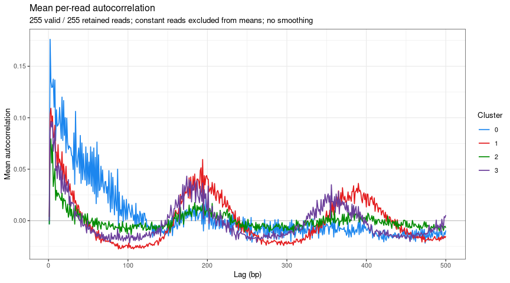

```r
plot_autocorrelation(lcl_acf, group_by = "acf_cluster", lag_range = c(1, 500))
```

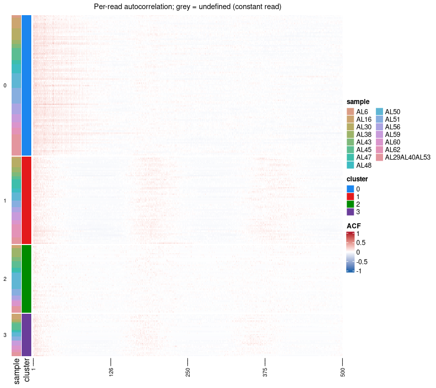

```r
ComplexHeatmap::draw(plot_autocorrelation(lcl_acf, "heatmap",
    group_by = "acf_cluster", lag_range = c(1, 500)))
```

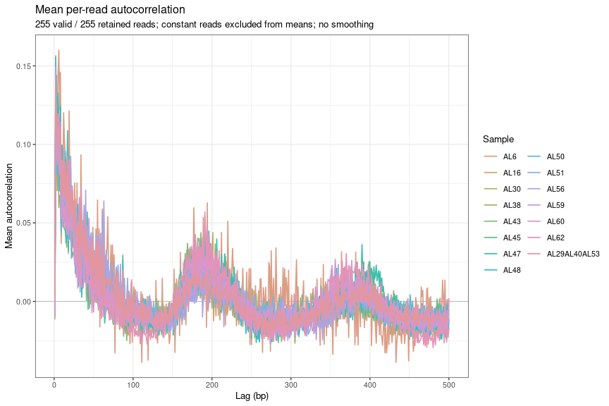

```r
plot_autocorrelation(lcl_acf, group_by = "sample", lag_range = c(1, 500))
```

## Export results

### Save the Leiden and autocorrelation analyses separately

`write_locus_results()` preserves the original Manhattan analysis. `write_autocorrelation_results()` saves the independent ACF experiment with both label columns. Output directories must be new or empty.

```r
write_locus_results(leiden_results, file.path(run_dir, "LCL-subset-leiden"))
write_autocorrelation_results(acf_clustered, file.path(run_dir, "LCL-subset-autocorrelation"))
if (params$run_lcl)
    write_autocorrelation_results(lcl_acf, file.path(run_dir, "LCL-autocorrelation"))
knitr::kable(data.frame(file = list.files(file.path(run_dir, "LCL-subset-autocorrelation"))))
```

| file |
| --- |
| acf_edges.tsv |
| acf_heatmap_acf_cluster.pdf |
| acf_heatmap_all.pdf |
| acf_heatmap_cluster.pdf |
| acf_heatmap_sample.pdf |
| acf_profile_acf_cluster.pdf |
| acf_profile_acf_cluster.tsv |
| acf_profile_all.pdf |
| acf_profile_all.tsv |
| acf_profile_cluster.pdf |
| acf_profile_cluster.tsv |
| acf_profile_sample.pdf |
| acf_profile_sample.tsv |
| autocorrelation.rds |
| lags.tsv |
| reads.tsv |

The ACF export contains `autocorrelation.rds`, `reads.tsv`, `lags.tsv`, mean/SD/SEM tables, profile/heatmap PDFs, and `acf_edges.tsv` when clustering was requested. For an `analyze_loci(..., autocorrelation = TRUE)` result, `write_locus_results()` exports its attached ACF automatically under each locus’s `autocorrelation/` subdirectory. To reload a standalone ACF result:

```r
restored_acf <- readRDS(file.path(run_dir, "LCL-subset-autocorrelation", "autocorrelation.rds"))
stopifnot(identical(assay(restored_acf), assay(acf_clustered)),
          identical(colData(restored_acf), colData(acf_clustered)))
```